# Chlorophyll variable name mystery

E. Klein

2019-04-18

Last run 2019-04-19 10:43:16

# INTRODUCTION

In the CTD profiles and WQM burst average data collection you might encounter different names for the derived chlorophyll parameter. In a quick revision of the full collections three different names exists:

- `CHLF`: Chlorophyll estimate from fluorescence readings using *factory* provided coefficients. In the ncdf metadata: “mass_concentration_of_inferred_chlorophyll_from_relative_fluorescence_units_in_sea_water,Concentration of inferred chlorophyll from relative fluorescence per unit volume of the water body,conversion from fluorescence to chlorophyll-a using factory coefficients,Milligrams per cubic metre,mg m-3”
- `CHLU`: Chlorophyll estimate from fluorescence readings using *user* provided coefficients. “mass_concentration_of_inferred_chlorophyll_from_relative_fluorescence_units_in_sea_water,Concentration of inferred chlorophyll from relative fluorescence per unit volume of the water body,conversion from fluorescence to chlorophyll-a using user coefficients,Milligrams per cubic metre,mg m-3”
- `CPHL`: Chlorophyll estimate from fluorescence readings using an *unknown* coefficient. In the ncdf metadata: “mass_concentration_of_inferred_chlorophyll_from_relative_fluorescence_units_in_sea_water,Concentration of inferred chlorophyll from relative fluorescence per unit volume of the water body,conversion from fluorescence to chlorophyll-a using unknown coefficients,Milligrams per cubic metre,mg m-3”

The idea is determine when and where those variables are present and to test if there are differences between the estimates when they are present in the same instrument.

# CTD profiles

## Data Collection

The data is pulled from the geoserver service using the following query:

`http://geoserver-123.aodn.org.au/geoserver/ows?typeName=anmn_ctd_profiles_data&SERVICE=WFS&outputFormat=csv&REQUEST=GetFeature&VERSION=1.0.0*`

The metadata was pulled using the following query:

`http://geoserver-123.aodn.org.au/geoserver/ows?typeName=anmn_ctd_profiles_map&SERVICE=WFS&outputFormat=csv&REQUEST=GetFeature&VERSION=1.0.0*`

The resulting table is stored locally so no need to repeat the geoserver query.

```r
## read CTD profiles from local file
CTD <- read_csv("IMOS_-_Australian_National_Mooring_Network_(ANMN)_-_CTD_Profiles.csv", skip=29)

## read metadata from the geoserver
CTD.map = read_csv("http://geoserver-123.aodn.org.au/geoserver/ows?typeName=anmn_ctd_profiles_map&SERVICE=WFS&outputFormat=csv&REQUEST=GetFeature&VERSION=1.0.0*")


## set chlorophyll variables as numeric
CTD$CHLF = as.numeric(CTD$CHLF)
CTD$CHLU = as.numeric(CTD$CHLU)
CTD$CPHL = as.numeric(CTD$CPHL)
```

The collection contains 107570 CTD profiles from338 cruises

```r
## uncomment to re-run
##
# CHL = CTD %>% group_by(file_id) %>%
#   summarise(CHLF = sum(!is.na(CHLF)),
#             CHLU = sum(!is.na(CHLU)),
#             CPHL = sum(!is.na(CPHL)))
#
#
# ## add metadata
# CHL = left_join(CHL, CTD.map)
#
# ## get the name of the instrument from the thredds server
# ## as it is not in the .map file I need to get it from each individual file
# ## this operation could take ~5mins as there are ~1600 files to open
# urlPrefix = "http://thredds.aodn.org.au/thredds/dodsC/"
# instrument=character()
#
# for (i in 1:nrow(CHL)){
#   print(i)
#   nc=nc_open(paste0(urlPrefix, CHL$url[i]))
#   instrument = append(instrument, ncatt_get(nc,0)$instrument)
#   nc_close(nc)
# }
#
# CHL$instrument = instrument
#
# write_csv(CHL, "CHL.csv")
```

```r
## read the metadata
## already processed file
CHL = read_csv("CHL.csv")
```

### Who is measuring what

A table of the instruments per chlorophyll variable

No instrument is reporting `CHLU`

```r
instrumentVariable = data.frame(Variable = c("CHLF", "CHLU", "CPHL"),
                                Instruments = c(paste0(unique(CHL$instrument[CHL$CHLF!=0]), collapse = ", "),
                                                paste0(unique(CHL$instrument[CHL$CHLU!=0]), collapse = ", "),
                                                paste0(unique(CHL$instrument[CHL$CPHL!=0]), collapse = ", ")))

knitr::kable(instrumentVariable)
```

| Variable | Instruments |
| --- | --- |
| CHLF | Seabird SBE19plus, SEABIRD CTD - SBE19PLUS V2 SEACAT, SEABIRD CTD - SBE 9 Plus, SEABIRD CTD - SBE19Plus, SEABIRD SBE19plus V2, SEA-BIRD ELECTRONICS SBE19PLUSV2 |
| CHLU |  |
| CPHL | RBR XR620, SEA-BIRD ELECTRONICS SBE19PLUSV2, SEABIRD SEACATPLUS V 1.4D, SEABIRD SBE19 PLUS V 2.2C, SEABIRD SBE19 PLUS V 2.1, SEABIRD SBE19plus V2, Seabird SBE19plus, SEABIRD CTD - SBE19PLUS V2 SEACAT,… |

## CHL variables by Station

This table shows the number of profiles that include each of the variable per `site_code`.

```r
siteCHL = CTD %>% group_by(site_code) %>% summarise(CHLF = length(unique(file_id[!is.na(CHLF)])),
                                                    CPHL = length(unique(file_id[!is.na(CPHL)])))

knitr::kable(siteCHL)
```

| site_code | CHLF | CPHL |
| --- | --- | --- |
| B1 | 0 | 1 |
| B2 | 0 | 1 |
| B3 | 0 | 1 |
| B5 | 0 | 1 |
| BMP070 | 0 | 9 |
| BMP090 | 0 | 11 |
| BMP120 | 0 | 19 |
| CH050 | 0 | 18 |
| CH070 | 0 | 29 |
| CH100 | 0 | 30 |
| CJ1 | 0 | 4 |
| CJ2 | 0 | 4 |
| CJ3 | 0 | 4 |
| GA06N | 0 | 4 |
| GA07M | 0 | 4 |
| GA08L | 0 | 4 |
| GA08N | 0 | 4 |
| GA09K | 0 | 4 |
| GA09M | 0 | 4 |
| GA10J | 0 | 4 |
| GA11I | 0 | 4 |
| GA11M | 0 | 4 |
| GA12H | 0 | 4 |
| GA13M | 0 | 4 |
| GA14F | 0 | 6 |
| GA15G | 0 | 6 |
| GA15M | 0 | 4 |
| GA16H | 0 | 6 |
| GA18J | 0 | 7 |
| GA19K | 0 | 9 |

[output cut: 69 more lines]

# WQM timeseries

## Data collection

The data (burst averaged collection) is pulled from the geoserver service using the following query:

data: `http://geoserver-123.aodn.org.au/geoserver/ows?typeName=anmn_burst_avg_timeseries_data&SERVICE=WFS&outputFormat=csv&REQUEST=GetFeature&VERSION=1.0.0&`

metadata: `http://geoserver-123.aodn.org.au/geoserver/ows?typeName=anmn_burst_avg_timeseries_map&SERVICE=WFS&outputFormat=csv&REQUEST=GetFeature&VERSION=1.0.0`

As the file are quite big, I will pull the data by `site_code`, one by one. Also see if there are concomitant measurements of two chlorophyll variables. The result table is stored for future needs.

```r
# get metadata first
WQM.map <- read_csv("http://geoserver-123.aodn.org.au/geoserver/ows?typeName=anmn_burst_avg_timeseries_map&SERVICE=WFS&outputFormat=csv&REQUEST=GetFeature&VERSION=1.0.")
## get the name of sites
sitenames = unique(WQM.map$site_code)


##
## uncomment to re-run
##


# WQM.chl = data.frame(site_code = character(),
#                      CHLF = numeric(),
#                      CHLU = numeric(),
#                      CPHL = numeric(),
#                      CHLFCHLU = logical(),
#                      CHLFCPHL = logical(),
#                      CHLUCPHL = logical())
#
# for (i in 1: length(sitenames)){
#
#   print(paste0(i, " - ", sitenames[i]))
#
#   GEOquery = paste0("http://geoserver-123.aodn.org.au/geoserver/ows?typeName=anmn_burst_avg_timeseries_data&SERVICE=WFS&outputFormat=csv&REQUEST=GetFeature&VERSION=1.0.0&CQL_FILTER=(site_code%20LIKE%20'", sitenames[i], "')")
#   WQM.data = suppressMessages(read_csv(GEOquery))
#
#
#   WQM.chl = bind_rows(WQM.chl, data.frame(site_code = sitenames[i],
#                                           CHLF = length(unique(WQM.data$timeseries_id[!is.na(WQM.data$CHLF)])),
#                                           CHLU = length(unique(WQM.data$timeseries_id[!is.na(WQM.data$CHLU)])),
#                                           CPHL = length(unique(WQM.data$timeseries_id[!is.na(WQM.data$CPHL)])),
#                                           CHLFCHLU = ifelse(sum(!is.na(WQM.data$CHLF) & !is.na(WQM.data$CHLU))>0,
#                                                             TRUE, FALSE),
#                                           CHLFCPHL = ifelse(sum(!is.na(WQM.data$CHLF) & !is.na(WQM.data$CPHL))>0,
#                                                             TRUE, FALSE),
#                                           CHLUCPHL = ifelse(sum(!is.na(WQM.data$CHLU) & !is.na(WQM.data$CPHL))>0,
#                                                             TRUE, FALSE)
#                                           ))
#
# }
#
# write_csv(WQM.chl, "WQMchl.csv")

WQM.chl = read_csv("WQMchl.csv")

knitr::kable(WQM.chl)
```

| site_code | CHLF | CHLU | CPHL | CHLFCHLU | CHLFCPHL | CHLUCPHL |
| --- | --- | --- | --- | --- | --- | --- |
| NRSKAI | 0 | 2 | 0 | FALSE | FALSE | FALSE |
| SAM8SG | 0 | 0 | 0 | FALSE | FALSE | FALSE |
| GBRCCH | 0 | 6 | 19 | FALSE | FALSE | FALSE |
| ITFJBG | 0 | 2 | 10 | FALSE | FALSE | FALSE |
| NRSMAI | 0 | 0 | 53 | FALSE | FALSE | FALSE |
| GBRHIS | 0 | 0 | 15 | FALSE | FALSE | FALSE |
| SAM5CB | 0 | 0 | 0 | FALSE | FALSE | FALSE |
| GBROTE | 0 | 1 | 11 | FALSE | FALSE | FALSE |
| GBRLSH | 0 | 4 | 15 | FALSE | FALSE | FALSE |
| GBRPPS | 0 | 8 | 20 | FALSE | FALSE | FALSE |
| GBRMYR | 0 | 3 | 11 | FALSE | FALSE | FALSE |
| PH100 | 24 | 24 | 2 | TRUE | FALSE | FALSE |
| NRSNSI | 0 | 0 | 65 | FALSE | FALSE | FALSE |
| NRSYON | 1 | 16 | 16 | FALSE | FALSE | FALSE |
| SYD100 | 7 | 7 | 1 | TRUE | FALSE | FALSE |
| SAM1DS | 0 | 0 | 0 | FALSE | FALSE | FALSE |
| SAM2CP | 0 | 0 | 0 | FALSE | FALSE | FALSE |
| SAM3MS | 0 | 0 | 0 | FALSE | FALSE | FALSE |
| SAM4CY | 0 | 0 | 0 | FALSE | FALSE | FALSE |
| SAM6IS | 0 | 0 | 0 | FALSE | FALSE | FALSE |
| SAM7DS | 0 | 0 | 0 | FALSE | FALSE | FALSE |
| PIL050 | 0 | 0 | 1 | FALSE | FALSE | FALSE |
| NRSROT | 49 | 0 | 0 | FALSE | FALSE | FALSE |
| NRSESP | 34 | 0 | 0 | FALSE | FALSE | FALSE |
| NRSDAR | 0 | 4 | 14 | FALSE | FALSE | FALSE |
| NRSNIN | 0 | 2 | 16 | FALSE | FALSE | FALSE |
| DARBGF | 0 | 0 | 3 | FALSE | FALSE | FALSE |
| WATR20 | 0 | 0 | 1 | FALSE | FALSE | FALSE |

At PH100 and SYD100 have concomitant measurements of `CHLU` and `CHLF`. Let’s explore the relationship between both.

### PH100

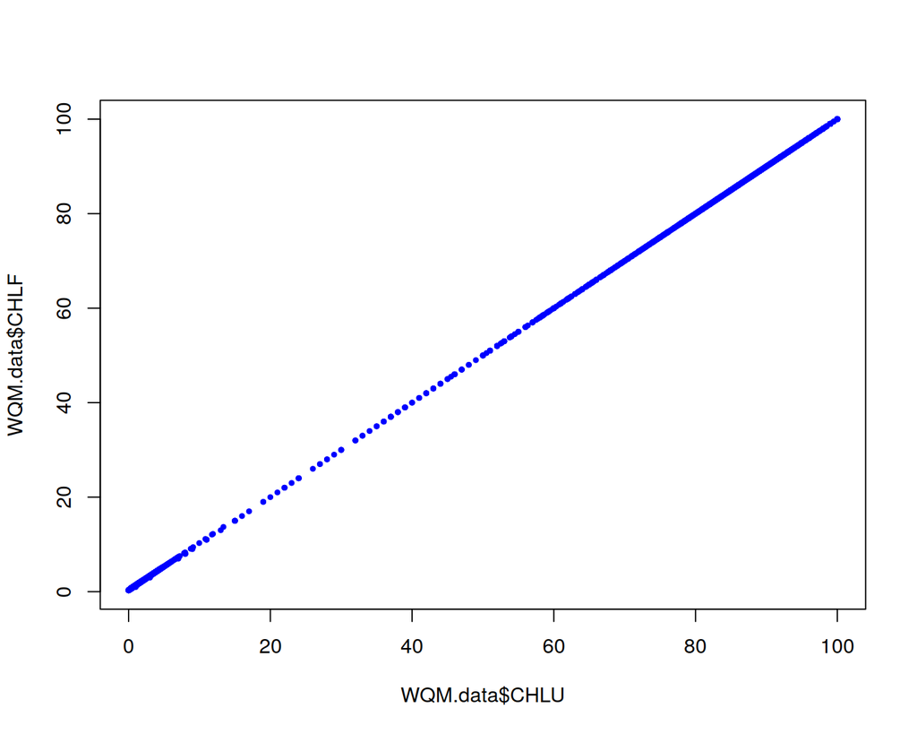

```r
i=12 ## PH100
GEOquery = paste0("http://geoserver-123.aodn.org.au/geoserver/ows?typeName=anmn_burst_avg_timeseries_data&SERVICE=WFS&outputFormat=csv&REQUEST=GetFeature&VERSION=1.0.0&CQL_FILTER=(site_code%20LIKE%20'", sitenames[i], "')")
WQM.data = suppressMessages(read_csv(GEOquery))

plot(WQM.data$CHLU, WQM.data$CHLF, pch=19, cex=0.5, col="blue")
```

```r
model = lm(CHLU~CHLF, data=WQM.data)

CHLUCHLFbias.PH100 = mean(WQM.data$CHLU - WQM.data$CHLF, na.rm=T)

summary(model)
```

```
Call:
lm(formula = CHLU ~ CHLF, data = WQM.data)

Residuals:
     Min       1Q   Median       3Q      Max
-0.07344  0.00609  0.00808  0.01263  0.32099

Coefficients:
                Estimate   Std. Error t value            Pr(>|t|)
(Intercept) -0.324784447  0.000078585   -4133 <0.0000000000000002 ***
CHLF         1.003793243  0.000006987  143657 <0.0000000000000002 ***
---
Signif. codes:  0 '***' 0.001 '**' 0.01 '*' 0.05 '.' 0.1 ' ' 1

Residual standard error: 0.02605 on 115752 degrees of freedom
  (21305 observations deleted due to missingness)
Multiple R-squared:      1, Adjusted R-squared:      1
F-statistic: 2.064e+10 on 1 and 115752 DF,  p-value: < 0.00000000000000022
```

### SYD100

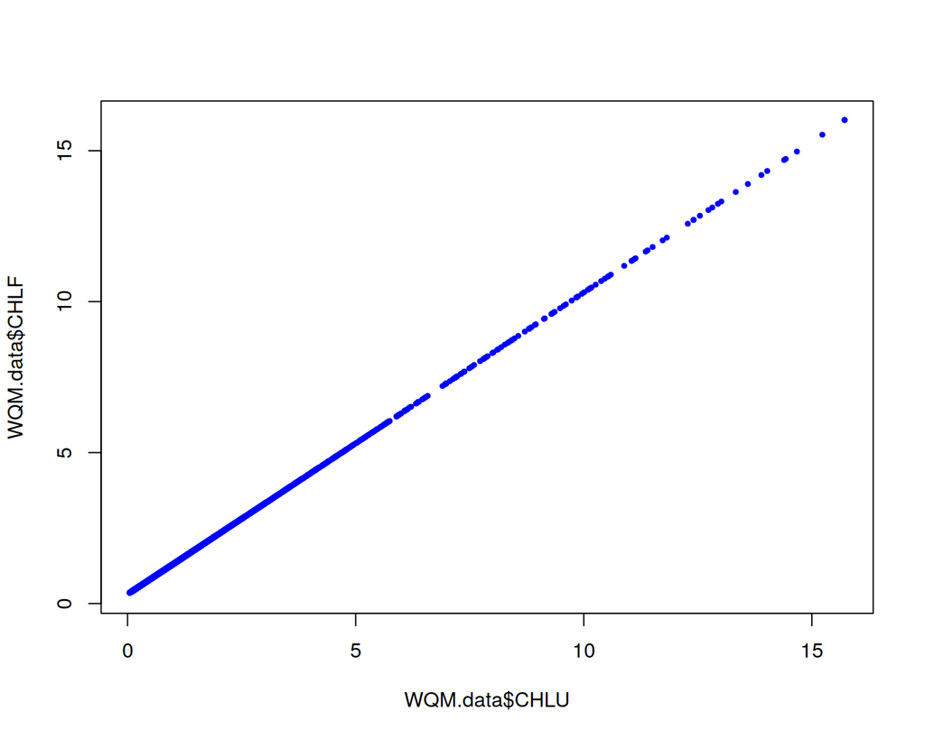

```r
i=15 ## SYD100
GEOquery = paste0("http://geoserver-123.aodn.org.au/geoserver/ows?typeName=anmn_burst_avg_timeseries_data&SERVICE=WFS&outputFormat=csv&REQUEST=GetFeature&VERSION=1.0.0&CQL_FILTER=(site_code%20LIKE%20'", sitenames[i], "')")
WQM.data = suppressMessages(read_csv(GEOquery))

plot(WQM.data$CHLU, WQM.data$CHLF, pch=19, cex=0.5, col="blue")
```

```r
model = lm(CHLU~CHLF, data=WQM.data)

CHLUCHLFbias.SYD100 = mean(WQM.data$CHLU - WQM.data$CHLF, na.rm=T)

summary(model)
```

```
Call:
lm(formula = CHLU ~ CHLF, data = WQM.data)

Residuals:
       Min         1Q     Median         3Q        Max
-0.0178894 -0.0013190 -0.0009555  0.0050740  0.0062558

Coefficients:
               Estimate  Std. Error t value            Pr(>|t|)
(Intercept) -0.30773391  0.00003703   -8310 <0.0000000000000002 ***
CHLF         1.00122990  0.00003026   33087 <0.0000000000000002 ***
---
Signif. codes:  0 '***' 0.001 '**' 0.01 '*' 0.05 '.' 0.1 ' ' 1

Residual standard error: 0.004306 on 32081 degrees of freedom
  (13378 observations deleted due to missingness)
Multiple R-squared:      1, Adjusted R-squared:      1
F-statistic: 1.095e+09 on 1 and 32081 DF,  p-value: < 0.00000000000000022
```

# CONCLUSIONS

# RECOMMENDATIONS

1. Add a new variable in each collection with the standard and unique name of `CHL` (and its corresponding burst statistics if applicable), and specify in the metadata the origin of the variable
2. Contact the BGC steering group to seek recommendation on what variable to use in case of the WQM register with `CHLU` and `CHLF` variables at the same timestamp.